# NIHS IBEC malaria dataset

Ibec team

2020-11-19

# Pipeline preparation

```r
library(AlpsLCMS)
library(xcms)
library(mixOmics)
library(MUVR)
```

Set your input and output folders:

```r
# Where samples are.
input_dir <- "C:/Users/hgracia/Desktop/IBEC/data/MTBLS665"

# Where output will be stored.
output_dir <- "C:/Users/hgracia/Desktop/IBEC/results/MTBLS665"
```

We may download the dataset into our PC running the following function. Warning: the following dataset contains numerous samples and might take long time to be downloaded:

```r
# Function to donwload data
download_data <- function(to = "./MTBLS665/") {
  if (!dir.exists(to)) {
    dir.create(to, recursive = TRUE)
  }
  url = "ftp://ftp.ebi.ac.uk/pub/databases/metabolights/studies/public/MTBLS665/"

  #We get the names of the files in the folder
  filenames <- RCurl::getURL(url, dirlistonly = TRUE)
  destnames <- strsplit(filenames, "\r*\n")[[1]]
  urls <- paste0(url, destnames)
  fls <- paste0(to, destnames)
  # Download files
  message("Downloading files, it will take some time")
  purrr::map2(urls, fls, function(urls, fls)
      utils::download.file(urls, destfile = fls, method = "auto", mode="wb"))
}

# Uncomment to download data
download_data(input_dir)
```

# NODE 1: Data wrangling

## Input

```r
# Where converted samples are.
path <- input_dir
```

# NODE 2: Append metadata

It requires a column (“sampleNames”) with the same name of the files, **ending with the format (e.g. So1.mzXML)**.

It requires a column (“treatment”) with the class sample. Ensure you have this specific colname **“treatment”**.

Caution with metadata. The use of characters such as “-”, “/”, " " (space) and starting with **numbers**, etc. leads to problems. Therefore, the function replace `[\\\"\\s/\\\\,;.:|#@$%&?!*%+-=><^'(){}\\[\\]]+` by `_`. Beware of using other special characters and change them by usual ASCII characters.

## Input parameters

```r
# Loading the metadata. # Be careful, include a column "sampleNames"
metadata_neg <- readxl::read_excel(
  "C:/Users/hgracia/Desktop/IBEC/data/MTBLS665/a_huc_c18neg.xlsx")
```

```
## * ...
```

```r
metadata_pos <- readxl::read_excel(
  "C:/Users/hgracia/Desktop/IBEC/data/MTBLS665/a_huc_hilicpos.xlsx")
```

```
## * ...
```

```r
# adding needed columns, treatment and sampleNames
# also added polarity but dont seems to be usefull in the metadata
metadata_neg[["treatment"]] <- metadata_neg[["Factor Value[Previous Malaria Infection]"]]
metadata_neg[["sampleNames"]] <- metadata_neg[["Raw Spectral Data File"]]
metadata_neg[["polarity"]] <- rep(0, length(metadata_neg[["sampleNames"]]))
metadata_pos[["treatment"]] <- metadata_pos[["Factor Value[Previous Malaria Infection]"]]
metadata_pos[["sampleNames"]] <- metadata_pos[["Raw Spectral Data File"]]
metadata_pos[["polarity"]] <- rep(1, length(metadata_neg[["sampleNames"]]))

#Sample selection, we select only the Diagnosis time point
selected_metadata_pos <- metadata_pos[
  (metadata_pos[["Factor Value[Time Point]"]] == "Diagnosis" &
     metadata_pos[["Factor Value[Time Point]"]] != "NA"),]
#We use metadata_pos because metadata_neg produces NA, at the end is the same
selected_metadata_neg <- metadata_neg[
  (metadata_pos[["Factor Value[Time Point]"]] == "Diagnosis" &
    metadata_neg[["Factor Value[Time Point]"]] != "NA"),]

#We remove outlayer VT_150411_133.cdf
selected_metadata_pos <- selected_metadata_pos[-7,]
```

## Load cdf files

```r
samples_pos <- fs::path_norm(paste(path, selected_metadata_pos[["sampleNames"]], sep = "/"))
samples_neg <- fs::path_norm(paste(path, selected_metadata_neg[["sampleNames"]], sep = "/"))

dataset <- readMSData(samples_pos, mode = "onDisk")
```

```
## Polarity can not be extracted from netCDF files, please set manually the polarity with the 'polarity' method.
```

```r
dataset_neg <- readMSData(samples_neg, mode = "onDisk")
```

```
## Polarity can not be extracted from netCDF files, please set manually the polarity with the 'polarity' method.
```

```r
message("Is the dataset correctly loaded? \n")
```

```
## Is the dataset correctly loaded?
```

```r
print(head(dataset))
```

```
## MSn experiment data ("OnDiskMSnExp")
## Object size in memory: 0.03 Mb
## - - - Spectra data - - -
##  MS level(s): 1
##  Number of spectra: 6
##  MSn retention times: 0:0 - 0:1 minutes
## - - - Processing information - - -
## Data loaded [Thu Nov 19 21:13:30 2020]
##  MSnbase version: 2.12.0
## - - - Meta data  - - -
## phenoData
##   rowNames: VT_150411_049.cdf
##   varLabels: sampleNames
##   varMetadata: labelDescription
## Loaded from:
##   VT_150411_049.cdf
## protocolData: none
## featureData
##   featureNames: F01.S0001 F01.S0002 ... F01.S0006 (6 total)
##   fvarLabels: fileIdx spIdx ... spectrum (33 total)
##   fvarMetadata: labelDescription
## experimentData: use 'experimentData(object)'
```

## Code to run

```r
dataset <- lcms_meta_add(dataset, selected_metadata_pos, by = "sampleNames")
dataset_neg <- lcms_meta_add(dataset_neg, selected_metadata_neg, by = "sampleNames")

#We add polarity to the datasets
dataset@featureData@data$polarity <- selected_metadata_pos[["polarity"]]
dataset_neg@featureData@data$polarity <- selected_metadata_neg[["polarity"]]
```

## Save results to disk

```r
output_dir_node2 <- file.path(output_dir, "02-add-metadata")
fs::dir_create(output_dir_node2)

dataset_rds <- fs::path(output_dir_node2, "dataset.rds")
lcms_dataset_save(dataset, dataset_rds)
dataset_rds <- fs::path(output_dir_node2, "dataset_neg.rds")
lcms_dataset_save(dataset_neg, dataset_rds)

lcms_meta_export(dataset, fs::path(output_dir_node2, "metadata.xlsx"))
lcms_meta_export(dataset_neg, fs::path(output_dir_node2, "metadata_neg.xlsx"))
```

## TICs

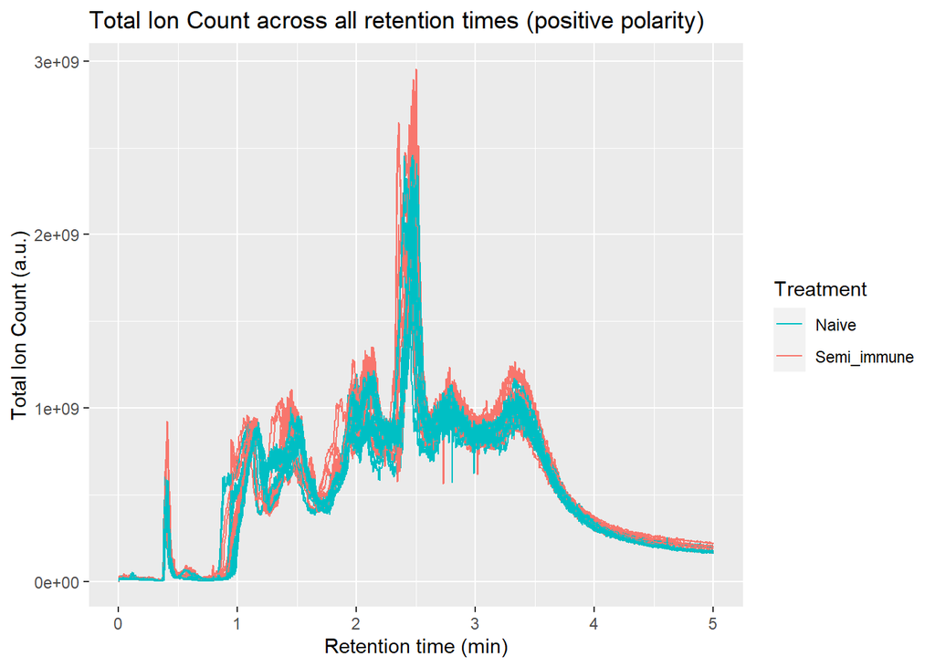

```r
tics_pos <- lcms_tics(dataset, treatment = "treatment")
tics_neg <- lcms_tics(dataset_neg, treatment = "treatment")

lcms_plot_tics(tics_pos,
               treatment = treatment,
               plot_type = "spec")
```

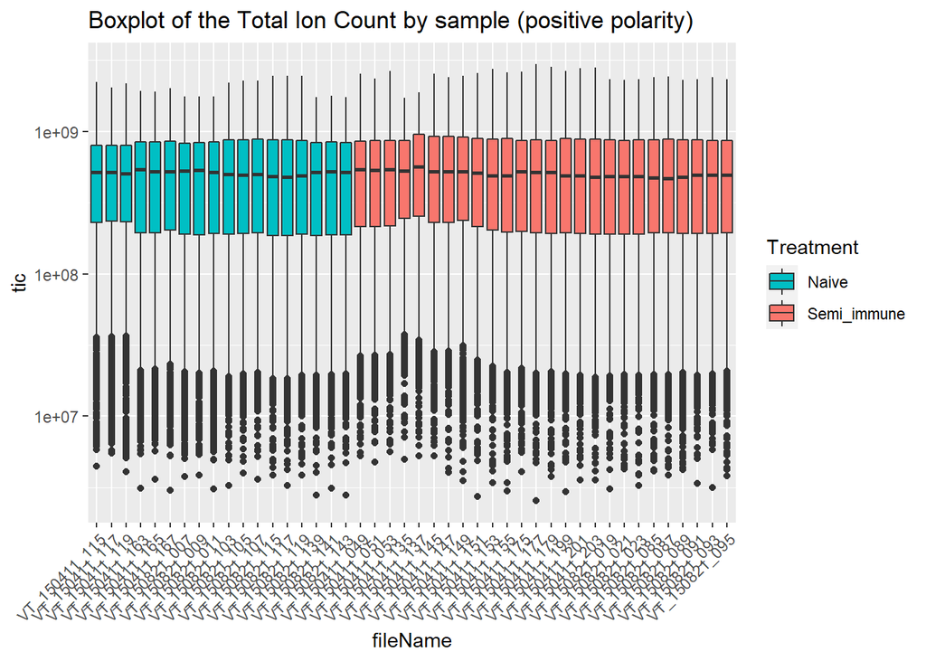

```r
lcms_plot_tics(tics_pos, treatment = treatment,
               plot_type = "boxplot")
```

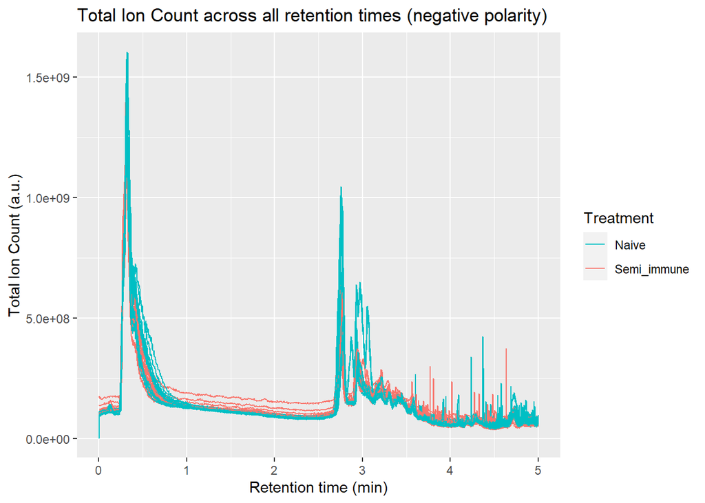

```r
lcms_plot_tics(tics_neg,
               treatment = treatment,
               plot_type = "spec")
```

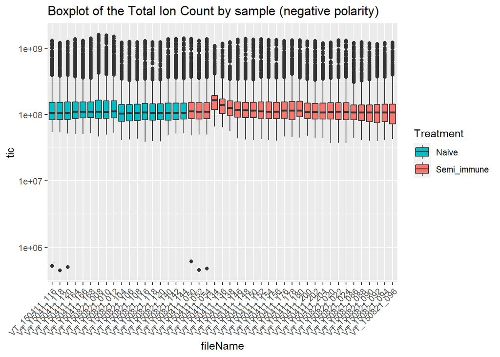

```r
lcms_plot_tics(tics_neg, treatment = treatment,
               plot_type = "boxplot")
```

## Save results

```r
output_dir_node3 <- file.path(output_dir, "03-split-mass_ranges")
fs::dir_create(output_dir_node3)

positive_dataset_rds1 <- fs::path(output_dir_node3, "positive_dataset.rds")
lcms_dataset_save(dataset, positive_dataset_rds1)
lcms_meta_export(dataset, fs::path(output_dir_node3, "metadata.xlsx"))

negative_dataset_rds1 <- fs::path(output_dir_node3, "negative_dataset.rds")
lcms_dataset_save(dataset_neg, negative_dataset_rds1)
lcms_meta_export(dataset_neg, fs::path(output_dir_node3, "metadata_neg.xlsx"))
```

# NODE 5: Optimization of parameters

## Optimization of **Peak Detection** parameters

Here, we try to fit the parameters obtained from the positive mode.

## Input

```r
output_dir_node5_p <- file.path(output_dir, "05-optimization_pos")
fs::dir_create(output_dir_node5_p)
output_dir_node5_n <- file.path(output_dir, "05-optimization_neg")
fs::dir_create(output_dir_node5_n)

# if to optimize or not
optimize = FALSE

# number of rounds, by default nSlaves = 1 because does the necessary to find the optimum
nSlaves = 1
```

## Code to run

```r
default_peakpeaking_params <- default_peakpicking_params(optimize = optimize)

resultPeakpicking_p<- peakpicking_optimization(
  dataset = dataset,
  peakpickingParameters = default_peakpeaking_params,
  nSlaves = nSlaves,
  opt_path = output_dir_node5_p,
  plots = TRUE)

resultPeakpicking_n<- peakpicking_optimization(
  dataset = dataset_neg,
  peakpickingParameters = default_peakpeaking_params,
  nSlaves = nSlaves,
  opt_path = output_dir_node5_n,
  plots = TRUE)
```

###Peak optimization results are stored in the variable `optimizedXcmsSetObject`

```r
optimizedXcmsSetObject_p <- resultPeakpicking_p$best_settings$xset
optimizedXcmsSetObject_n <- resultPeakpicking_n$best_settings$xset
```

## Save results

```r
# Positive
resultPeakpicking_optP_rds <- fs::path(output_dir_node5_p,
                                      "resultPeakpicking_opt_p.rds")
lcms_dataset_save(resultPeakpicking_p,
                  resultPeakpicking_optP_rds)

optimizedXcmsSetObjectP_rds <- fs::path(output_dir_node5_p,
                                    "optimizedXcmsSetObject_p.rds")

lcms_dataset_save(optimizedXcmsSetObject_p,
                  optimizedXcmsSetObjectP_rds)

#Negative
resultPeakpicking_optN_rds <- fs::path(output_dir_node5_n,
                                      "resultPeakpicking_opt_n.rds")
lcms_dataset_save(resultPeakpicking_n,
                  resultPeakpicking_optN_rds)

optimizedXcmsSetObjectN_rds <- fs::path(output_dir_node5_n,
                                    "optimizedXcmsSetObject_n.rds")

lcms_dataset_save(optimizedXcmsSetObject_n,
                  optimizedXcmsSetObjectN_rds)
```

## Optimization of **retention time correction** and **grouping** parameters

## Input: We set them manually (optimize = FALSE)

```r
optimize = FALSE
nSlaves = 1

output_dir_node5_p
```

```
## [1] "C:/Users/hgracia/Desktop/IBEC/results/MTBLS665/05-optimization_pos"
```

## Code to run (I)

```r
retcorGroupParameters <- lcms_default_retcorgroup_params(optimize = optimize)
```

## Code to run (II)

```r
resultRetcorGroup_p  <- lcms_retcorgroup_optimization(
  optimizedXcmsSetObject = optimizedXcmsSetObject_p,
  retcorGroupParameters = retcorGroupParameters,
  nSlaves = nSlaves,
  opt_path = output_dir_node5_p,
  subdir = "plot_ipo",
  plots = TRUE
)

resultRetcorGroup_n  <- lcms_retcorgroup_optimization(
  optimizedXcmsSetObject = optimizedXcmsSetObject_n,
  retcorGroupParameters = retcorGroupParameters,
  nSlaves = nSlaves,
  opt_path = output_dir_node5_p,
  subdir = "plot_ipo",
  plots = TRUE
)
```

## Save results

```r
resultRetcorGroup_optP_rds <- fs::path(output_dir_node5_p,
                                      "resultRetcorGroup_opt_p.rds")
lcms_dataset_save(resultRetcorGroup_p,
                  resultRetcorGroup_optP_rds)

### Important file
IPO_params_p = lcms_write_opt_params(resultPeakpicking_p,
                                     resultRetcorGroup_p,
                                     output_dir_node5_p)
```

```
## library(xcms)
```

```
## library(Rmpi)
```

```
## xset <- xcmsSet(
##   method = "centWave",
##   peakwidth       = c(10, 50),
##   ppm             = 25,
##   noise           = 500,
##   snthresh        = 5,
##   mzdiff          = -0.001,
##   prefilter       = c(3, 100),
##   mzCenterFun     = "wMean",
##   integrate       = 1,
##   fitgauss        = FALSE,
##   verbose.columns = FALSE)
```

```
## xset <- retcor(
##   xset,
##   method         = "obiwarp",
##   plottype       = "none",
##   distFunc       = "cor_opt",
##   profStep       = 1,
##   center         = ,
##   response       = 1,
##   gapInit        = ,
##   gapExtend      = ,
##   factorDiag     = 2,
##   factorGap      = 1,
##   localAlignment = 0)
```

```
## xset <- group(
##   xset,
##   method  = "density",
##   bw      = 30,
##   mzwid   = 0.25,
##   minfrac = 0.3,
##   minsamp = 1,
##   max     = 50)
```

```
## xset <- fillPeaks(xset)
```

```r
resultRetcorGroup_optN_rds <- fs::path(output_dir_node5_n,
                                      "resultRetcorGroup_opt_n.rds")
lcms_dataset_save(resultRetcorGroup_n,
                  resultRetcorGroup_optN_rds)

### Important file
IPO_params_n = lcms_write_opt_params(resultPeakpicking_n,
                                     resultRetcorGroup_n,
                                     output_dir_node5_n)
```

```
## library(xcms)
```

```
## library(Rmpi)
```

```
## xset <- xcmsSet(
##   method = "centWave",
##   peakwidth       = c(10, 50),
##   ppm             = 25,
##   noise           = 500,
##   snthresh        = 5,
##   mzdiff          = -0.001,
##   prefilter       = c(3, 100),
##   mzCenterFun     = "wMean",
##   integrate       = 1,
##   fitgauss        = FALSE,
##   verbose.columns = FALSE)
```

```
## xset <- retcor(
##   xset,
##   method         = "obiwarp",
##   plottype       = "none",
##   distFunc       = "cor_opt",
##   profStep       = 1,
##   center         = ,
##   response       = 1,
##   gapInit        = ,
##   gapExtend      = ,
##   factorDiag     = 2,
##   factorGap      = 1,
##   localAlignment = 0)
```

```
## xset <- group(
##   xset,
##   method  = "density",
##   bw      = 30,
##   mzwid   = 0.25,
##   minfrac = 0.3,
##   minsamp = 1,
##   max     = 50)
```

```
## xset <- fillPeaks(xset)
```

# NODE 6: Conversion to xcms and data rearrange

First, we need the conversion from `IPO` to `XCMS` variable formats to achieve compatibility between packages. To do that, we need to read the IPO_params from the last step and convert into XCMS frame.

# NODE 7: Data Preprocessing - XCMS

It includes:

- Peak Detection
- Retention Time Correction
- Peak Correspondence
- Imputation

## Checking L-Valine

POS HMDB00883 3 L-Valine 118,0862 124,7 Multiple 118,08625 0,42 C5H11NO2 117,0789786 M+H 5789138582  
NEG HMDB00883 2 L-Valine 116.0717 162.3 Multiple 116.0717 0 C5H11NO2 117.0789786 M-H 4457969.5

```r
metabolite <- "L-Valine"
retention_time <- 124.7
mz <- 118.0862

retention_time_max <- (retention_time)+15
retention_time_min <- (retention_time)-15
rtr <- c(retention_time_min, retention_time_max)

metabolite_neg <- "L-Valine"
retention_time_neg <- 162.3
mz_neg <- 116.0717

retention_time_max_neg <- (retention_time_neg)+15
retention_time_min_neg <- (retention_time_neg)-15
rtr_neg <- c(retention_time_min_neg, retention_time_max_neg)
```

## Code to run

[figure not shown]

```r
cromplot(dataset, rt = retention_time, mz = mz, metabolite = metabolite)
```

[figure not shown]

```r
cromplot(dataset_neg, rt = retention_time_neg, mz = mz_neg, metabolite = metabolite_neg)
```

## Input

```r
output_dir_node5_p <- file.path(output_dir, "05-optimization_pos")
directory_params_p <- output_dir_node5_p

prep_parm_p <- lcms_read_ipo_to_xcms(directory_params_p)
prep_parm_p$peakwidth <- c(8, 60)
prep_parm_p$noise <- 1e+4
prep_parm_p$snthresh <- 3
prep_parm_p$prefilter <- c(3, 1e+4)
prep_parm_p$centerSample <- 1 # index of the center sample.
prep_parm_p$integrate <- 2
prep_parm_p$mzdiff <- -0.001
prep_parm_p$profStep <- 0.005
prep_parm_p$minFraction <- 0.2

classes <- dataset@phenoData@data[["treatment"]]
```

```r
output_dir_node5_n <- file.path(output_dir, "05-optimization_neg")
directory_params_n <- output_dir_node5_n

prep_parm_n <- lcms_read_ipo_to_xcms(directory_params_n)
prep_parm_n$peakwidth <- c(8, 60)
prep_parm_n$noise <- 1e+4
prep_parm_n$snthresh <- 3
prep_parm_n$prefilter <- c(3, 1e+4)
prep_parm_n$centerSample <- 1 # index of the center sample.
prep_parm_n$integrate <- 2
prep_parm_n$mzdiff <- -0.001
prep_parm_n$profStep <- 0.005
prep_parm_n$minFraction <- 0.2

classes_neg <- dataset_neg@phenoData@data[["treatment"]]
```

# **Peak detection**

Our standard method for peak detection is *‘CentWave’*, since the data provided is Centroided. We must initialize its parameters according to the `IPO` Package optimization. Peak detection aims to detect important features (peaks) on the chromatographic axis. This will be useful for a posterior peak alignment on the chormatophic axis.

## Code to run

```r
peakdet = find_peaks_cwp(dataset,
                         params = prep_parm_p)
```

```
##
##  Finding chromatographic peaks
```

```r
peakdet_neg = find_peaks_cwp(dataset_neg,
                             params = prep_parm_n)
```

```
##
##  Finding chromatographic peaks
```

```r
message("Number of detected peaks")
```

```
## Number of detected peaks
```

```r
peakdet@msFeatureData[["chromPeakData"]]@nrows
```

```
## [1] 300077
```

```r
message("")
message("Parameters")
```

```
## Parameters
```

```r
peakdet@.processHistory[[1]]@param
```

```
## Object of class:  CentWaveParam
## Parameters:
##  ppm: 25
##  peakwidth: 8, 60
##  snthresh: 3
##  prefilter: 3, 10000
##  mzCenterFun: wMean
##  integrate: 2
##  mzdiff: -0.001
##  fitgauss: FALSE
##  noise: 10000
##  verboseColumns: FALSE
##  roiList length: 0
##  firstBaselineCheck TRUE
##  roiScales length: 0
```

```r
message("Number of detected peaks")
```

```
## Number of detected peaks
```

```r
peakdet_neg@msFeatureData[["chromPeakData"]]@nrows
```

```
## [1] 202222
```

```r
message("")
message("Parameters")
```

```
## Parameters
```

```r
peakdet_neg@.processHistory[[1]]@param
```

```
## Object of class:  CentWaveParam
## Parameters:
##  ppm: 25
##  peakwidth: 8, 60
##  snthresh: 3
##  prefilter: 3, 10000
##  mzCenterFun: wMean
##  integrate: 2
##  mzdiff: -0.001
##  fitgauss: FALSE
##  noise: 10000
##  verboseColumns: FALSE
##  roiList length: 0
##  firstBaselineCheck TRUE
##  roiScales length: 0
```

# **Retention Time Correction and Peak Correspondence**

Peak correspondence is carried out by the *‘groupChromPeaks’* method, with parameters obtained form `IPO`. Peak Correspondece consist in grouping peaks on retention time axis with the purspose of associate them to spectra on the mass/chage axis. After this stage we finally have a peak table.

It requires a previous grouping.

# **Correspondence, Alignment and Regrouping**

## Input

```r
centerSample <- floor(median(1:length(fileNames(dataset))))
```

## **Correspondence**

```r
###################################################################
## CORRESPONDENCE
new_params <- PeakDensityParam(sampleGroups = classes,
                               bw = 5,
                               minFraction = 0.2,
                               minSamples = 1,
                               binSize = 0.005,
                               maxFeatures = 50)

peakgrouped = groupChromPeaks(peakdet,
                              param = new_params)
```

```
## Processing 475396 mz slices ... OK
```

```r
new_params_neg <- PeakDensityParam(sampleGroups = classes_neg,
                               bw = 5,
                               minFraction = 0.2,
                               minSamples = 1,
                               binSize = 0.005,
                               maxFeatures = 50)

peakgrouped_neg = groupChromPeaks(peakdet_neg,
                              param = new_params_neg)
```

```
## Processing 471490 mz slices ... OK
```

## **Alignment and regrouping**

```r
###################################################################
## ALIGNMENT

pgp <- PeakGroupsParam(minFraction = 0.4,
                       extraPeaks = 1,
                       smooth = "loess",
                       family = "gaussian",
                       subset = as.integer(
                    rownames(as.data.frame(dataset@phenoData@data))))

## Get the peak groups that would be used for alignment.
xdata_aling <- adjustRtime(peakgrouped, param = pgp)
```

```
## Performing retention time correction using 1254 peak groups.
```

```
## Applying retention time adjustment to the identified chromatographic peaks ... OK
```

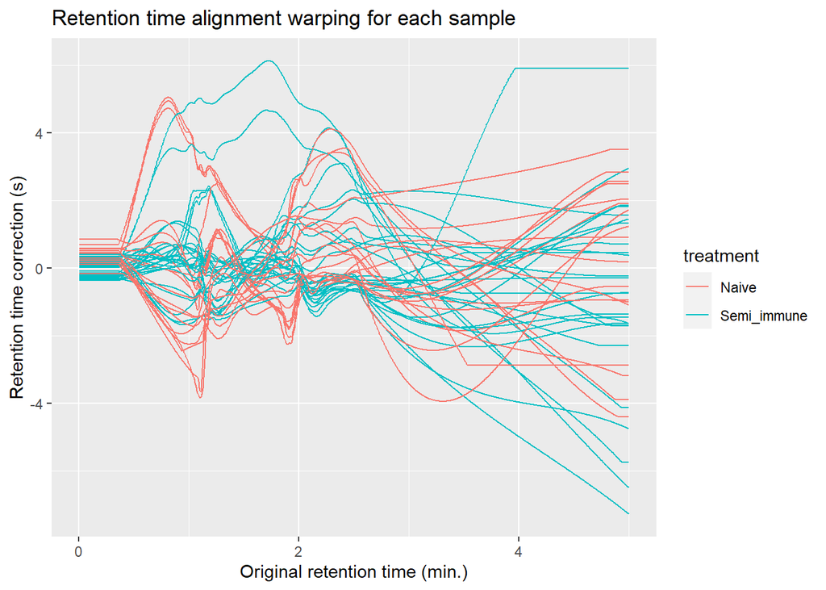

```r
rt_plot = lcms_retention_time_alignment_plot(xdata_aling)
rt_plot
```

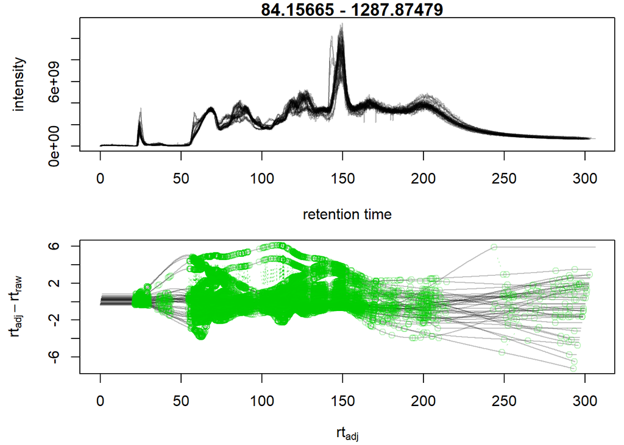

```r
clrs <- rep("#00000040", 8)
par(mfrow = c(2, 1), mar = c(4, 4.5, 1, 0.5))
plot(chromatogram(xdata_aling, aggregationFun = "sum"),
     col = clrs, peakType = "none")
plotAdjustedRtime(xdata_aling, col = clrs, peakGroupsPch = 1,
                  peakGroupsCol = "#00ce0040")
```

```r
###################################################################
## REGROUPING

new_params <- PeakDensityParam(sampleGroups = classes,
                               bw = 5, #
                               minFraction = 0.2,
                               minSamples = 1,
                               binSize = 0.005,
                               maxFeatures = 50)

peakgrouped = groupChromPeaks(xdata_aling, param = new_params)
```

```
## Processing 475396 mz slices ... OK
```

```r
###################################################################
## ALIGNMENT

pgp_neg <- PeakGroupsParam(minFraction = 0.4,
                       extraPeaks = 1,
                       smooth = "loess",
                       family = "gaussian",
                       subset = as.integer(
                  rownames(as.data.frame(dataset_neg@phenoData@data))))

## Get the peak groups that would be used for alignment.
xdata_aling_neg <- adjustRT(peakgrouped_neg, param = pgp_neg)
```

```
## Performing retention time correction using 604 peak groups.
```

```
## Applying retention time adjustment to the identified chromatographic peaks ... OK
```

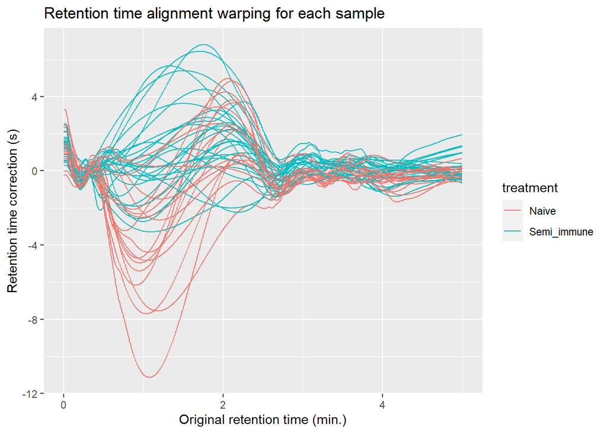

```r
rt_plot_neg = lcms_retention_time_alignment_plot(xdata_aling_neg)
rt_plot_neg
```

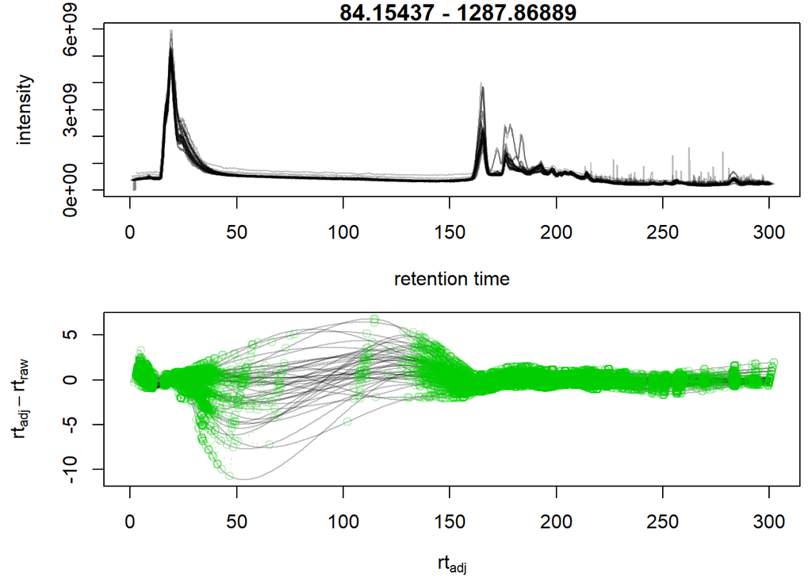

```r
clrs <- rep("#00000040", 8)
par(mfrow = c(2, 1), mar = c(4, 4.5, 1, 0.5))
plot(chromatogram(xdata_aling_neg, aggregationFun = "sum"),
     col = clrs, peakType = "none")
plotAdjustedRtime(xdata_aling_neg, col = clrs, peakGroupsPch = 1,
                  peakGroupsCol = "#00ce0040")
```

```r
###################################################################
## REGROUPING

new_params_neg <- PeakDensityParam(sampleGroups = classes_neg,
                               bw = 5, #
                               minFraction = 0.2,
                               minSamples = 1,
                               binSize = 0.005,
                               maxFeatures = 50)

peakgrouped_neg = groupChromPeaks(xdata_aling_neg, param = new_params_neg)
```

```
## Processing 471490 mz slices ... OK
```

Image plot of the chromatographic detected peaks per sample before retention time alignment and grouping:

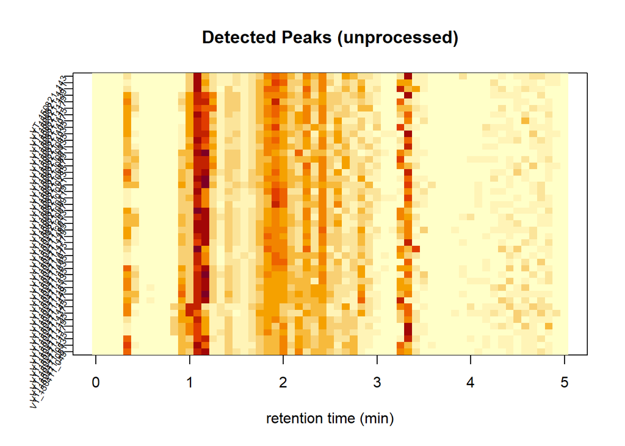

```r
lcms_plot_chrom_peak_image(peakdet, binSize = 5,
                           xlim = NULL,
                           log = FALSE,
                           xlab = "retention time (min)",
                           yaxt = par("yaxt"),
                           main = "Detected Peaks (unprocessed)")
```

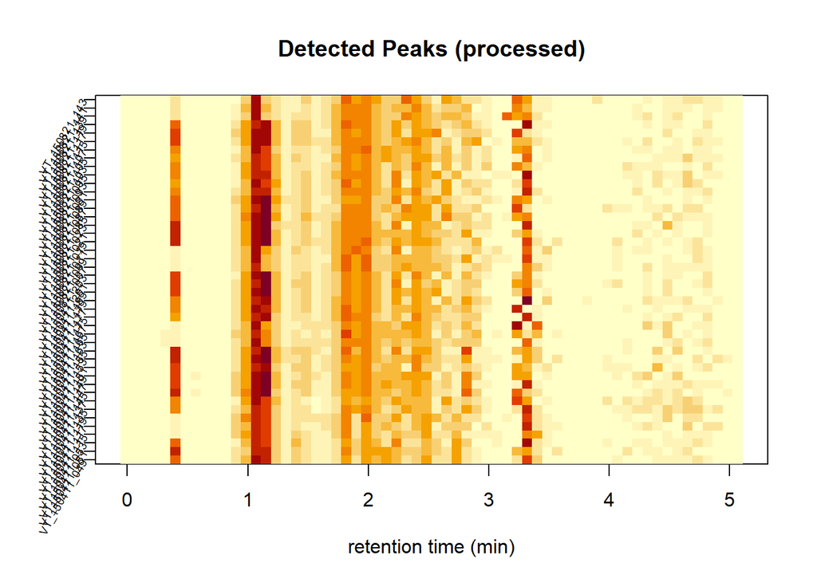

```r
lcms_plot_chrom_peak_image(peakgrouped, binSize = 5,
                           xlim = NULL,
                           log = FALSE,
                           xlab = "retention time (min)",
                           yaxt = par("yaxt"),
                           main = "Detected Peaks (processed)")
```

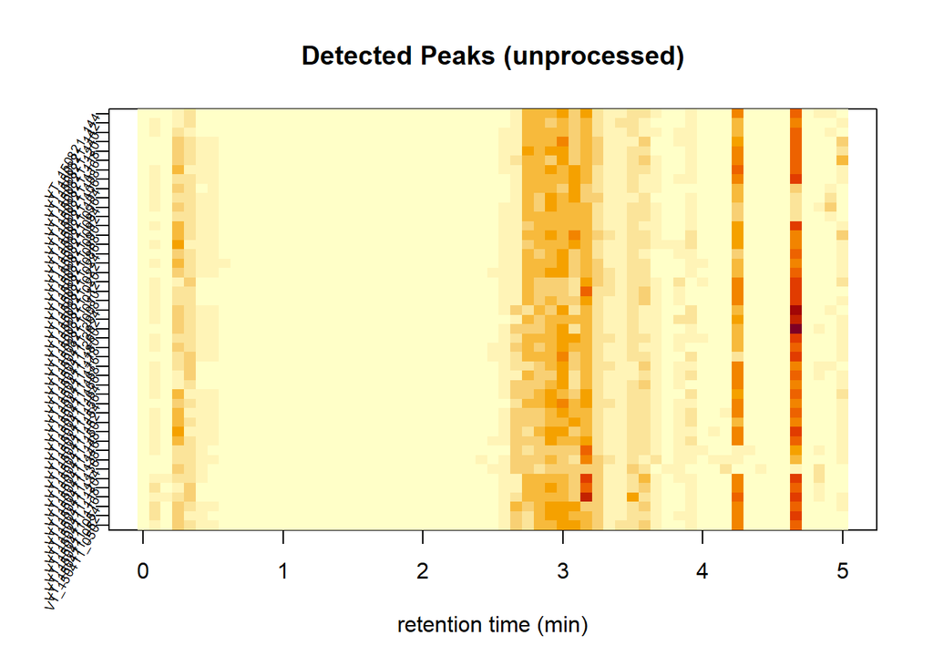

```r
lcms_plot_chrom_peak_image(peakdet_neg, binSize = 5,
                           xlim = NULL,
                           log = FALSE,
                           xlab = "retention time (min)",
                           yaxt = par("yaxt"),
                           main = "Detected Peaks (unprocessed)")
```

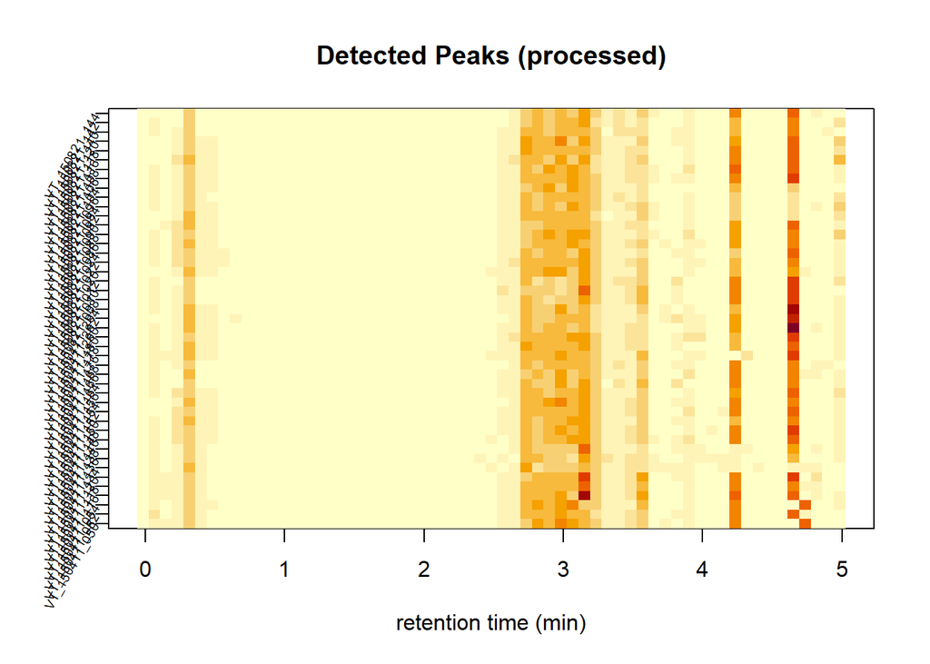

```r
lcms_plot_chrom_peak_image(peakgrouped_neg, binSize = 5,
                           xlim = NULL,
                           log = FALSE,
                           xlab = "retention time (min)",
                           yaxt = par("yaxt"),
                           main = "Detected Peaks (processed)")
```

# *Imputation*

Finally, in the imputation stage, we integrate the areas of the missing peaks of the peak table that were not detected in the previous steps of the signal preprocessing workflow. This stage is important to make easier statistical and machine learning posterior stages.

```r
message("Missing values found in the processed dataset: ",
        sum(is.na(feature_values(peakgrouped))))
```

```
## Missing values found in the processed dataset: 140264
```

```r
peakgrouped_imp <- lcms_fill_chrom_peaks(
  peakgrouped)
```

```
##
##  Imputing missing peaks of the peak table.
```

```r
cat("Imputing values...\n")
```

```
## Imputing values...
```

```r
message("Missing values found after fill_chrom_peaks: ",
        sum(is.na(feature_values(peakgrouped_imp))))
```

```
## Missing values found after fill_chrom_peaks: 10761
```

```r
message("Missing values found in the processed dataset: ",
        sum(is.na(feature_values(peakgrouped_neg))))
```

```
## Missing values found in the processed dataset: 80041
```

```r
peakgrouped_imp_neg <- lcms_fill_chrom_peaks(
  peakgrouped_neg)
```

```
##
##  Imputing missing peaks of the peak table.
```

```r
cat("Imputing values...\n")
```

```
## Imputing values...
```

```r
message("Missing values found after fill_chrom_peaks: ",
        sum(is.na(feature_values(peakgrouped_imp_neg))))
```

```
## Missing values found after fill_chrom_peaks: 10490
```

## Save results

```r
output_dir_node7 <- file.path(output_dir, "07-data-preprocessing")
fs::dir_create(output_dir_node7)

##################################################################
# PEAK DETECTION
detected_peak_rds <- fs::path(output_dir_node7, "detected_peaks.rds")
lcms_dataset_save(peakdet, detected_peak_rds)

##################################################################
# PEAK ALIGNMENT and GROUPING
aligned_peak_rds <- fs::path(output_dir_node7,
                                      "aligned_peak.rds")
lcms_dataset_save(peakgrouped,
                  aligned_peak_rds)

##################################################################
# SEMI IMPUTED PEAK TABLE
peaktable_pos_rds <- fs::path(output_dir_node7,
                               "peakTable_imp.rds")
lcms_dataset_save(peakgrouped_imp,
                  peaktable_pos_rds)

rt_alignment_plot <- file.path(output_dir_node7, "rt_alignment_plot.png")
ggplot2::ggsave(filename = rt_alignment_plot,
                plot = rt_plot,
                width = 14,
                height = 8,
                unit = "cm",
                dpi = 300)
##################################################################
# PEAK DETECTION
detected_peak_rds <- fs::path(output_dir_node7, "detected_peaks_neg.rds")
lcms_dataset_save(peakdet_neg, detected_peak_rds)

##################################################################
# PEAK ALIGNMENT and GROUPING
aligned_peak_rds <- fs::path(output_dir_node7,
                                      "aligned_peak_neg.rds")
lcms_dataset_save(peakgrouped_neg,
                  aligned_peak_rds)

##################################################################
# SEMI IMPUTED PEAK TABLE
peaktable_pos_rds <- fs::path(output_dir_node7,
                               "peakTable_imp_neg.rds")
lcms_dataset_save(peakgrouped_imp_neg,
                  peaktable_pos_rds)

rt_alignment_plot <- file.path(output_dir_node7, "rt_alignment_plot_neg.png")
ggplot2::ggsave(filename = rt_alignment_plot,
                plot = rt_plot_neg,
                width = 14,
                height = 8,
                unit = "cm",
                dpi = 300)
```

# NODE 8: Feature table

The XCMS function featureValues creates a intensity matrix with all the features. However, since this is untargeted metabolomics, the colnames are composed by FT1, FT2, FT3… (FT = feature) and each feature needs to be explored with the feature definition function (info for mass and rt) once a feature is significantly different by groups.

## Merging into a Feature Table

```r
xdata = feature_values(peakgrouped_imp,
                             method = "maxint",
                             value = "into",
                             filled = TRUE,
                             missing = NA)

xdata= t(xdata)
feature=featureDefinitions(peakgrouped_imp)
feature=feature@listData
featNames=paste0(feature$mzmed,"_",feature$rtmed)
colnames(xdata)=featNames

#Number of missing values after missing value imputation
message("Missing values in the feature table: ",
sum(is.na(xdata)))
```

```
## Missing values in the feature table: 10761
```

```r
xdata_neg = feature_values(peakgrouped_imp_neg,
                             method = "maxint",
                             value = "into",
                             filled = TRUE,
                             missing = NA)

xdata_neg= t(xdata_neg)
feature_neg=featureDefinitions(peakgrouped_imp_neg)
feature_neg=feature_neg@listData
featNames_neg=paste0(feature_neg$mzmed,"_",feature_neg$rtmed)
colnames(xdata_neg)=featNames_neg

#Number of missing values after missing value imputation
message("Missing values in the feature table: ",
sum(is.na(xdata_neg)))
```

```
## Missing values in the feature table: 10490
```

## Deep Imputation by Random Forest

```r
#Missing Value Imputation

nCore <- detectCores()-1
cl <- makeCluster(nCore)
doParallel::registerDoParallel(cl)
xdataImp <- StatTools::mvImpWrap(MAT = xdata,
                                        method = "RF")
xdataImp_neg <- StatTools::mvImpWrap(MAT = xdata_neg,
                                        method = "RF")
stopCluster(cl)

#Number of missing values after missing value imputation
sum(is.na(xdataImp))
sum(is.na(xdataImp_neg))
```

```r
xdataImputed <- as.data.frame(xdataImp, stringsAsFactors = FALSE)

#############################################
# Get mz and rt columns for the feature table
mz <- colnames(xdataImp) %>%
  stringr::str_split(.,"\\_") %>%
  lapply(.,function(x) x[1]) %>%
  unlist() %>%
  as.numeric()

rt <- colnames(xdataImp) %>%
  stringr::str_split(.,"\\_") %>%
  lapply(.,function(x) x[2]) %>%
  unlist() %>%
  as.numeric()
rt <- rt/60

xdata_complete <- cbind(rt, xdataImp)
xdata_complete <- cbind(mz, xdata_complete)
xdata_complete <- cbind(sampleNames = rownames(xdataImp), xdata_complete)
xdata_complete <- as.data.frame(xdata_complete)

suppressWarnings(
  xdata_comp_meta <- dplyr::right_join(
    metadata_pos,
    xdata_complete,
    by = "sampleNames",
    all = TRUE))

##############################
# Get transposed feature table
tdata_complete <- as.data.frame(t(as.matrix(xdata_complete)))
```

```r
xdataImputed_neg <- as.data.frame(xdataImp_neg, stringsAsFactors = FALSE)

#############################################
# Get mz and rt columns for the feature table
mz_neg <- colnames(xdataImp_neg) %>%
  stringr::str_split(.,"\\_") %>%
  lapply(.,function(x) x[1]) %>%
  unlist() %>%
  as.numeric()

rt_neg <- colnames(xdataImp_neg) %>%
  stringr::str_split(.,"\\_") %>%
  lapply(.,function(x) x[2]) %>%
  unlist() %>%
  as.numeric()
rt_neg <- rt_neg/60

xdata_complete_neg <- cbind(rt_neg, xdataImp_neg)
xdata_complete_neg <- cbind(mz_neg, xdata_complete_neg)
xdata_complete_neg <- cbind(sampleNames = rownames(xdataImp_neg), xdata_complete_neg)
xdata_complete_neg <- as.data.frame(xdata_complete_neg)

suppressWarnings(
  xdata_comp_meta_neg <- dplyr::right_join(
    metadata_neg,
    xdata_complete_neg,
    by = "sampleNames",
    all = TRUE))

##############################
# Get transposed feature table
tdata_complete_neg <- as.data.frame(t(as.matrix(xdata_complete_neg)))
```

## Save results

```r
output_dir_node8 <- file.path(output_dir, "08-feature-table")
fs::dir_create(output_dir_node8)

write.csv(xdata,
         file = paste0(getwd(),
                       "/xdata.csv"))

xdata_fn <- file.path(output_dir_node8,
                              "xdataNOTimp.csv")
utils::write.csv(xdata, xdata_fn, row.names = FALSE)

xdataImputed_fn <- file.path(output_dir_node8,
                              "xdataImputed.csv")
utils::write.csv(xdataImputed, xdataImputed_fn, row.names = FALSE)

data_complete_fn <- file.path(output_dir_node8,
                              "feature_table.csv")
utils::write.csv(xdata_complete, data_complete_fn, row.names = FALSE)

xdata_comp_meta_fn <- file.path(output_dir_node8,
                              "feature_tableMeta.csv")
utils::write.csv(xdata_comp_meta, xdata_comp_meta_fn, row.names = FALSE)

tdata_complete_fn <- file.path(output_dir_node8,
                              "feature_tableT.csv")
utils::write.csv(tdata_complete, tdata_complete_fn, row.names = FALSE)


xdata.csv_fn <- file.path(output_dir_node8, "xdata.csv")
utils::write.csv(xdata, xdata.csv_fn, row.names = TRUE)
```

```r
write.csv(xdata_neg,
         file = paste0(getwd(),
                       "/xdata_neg.csv"))

xdata_fn <- file.path(output_dir_node8,
                              "xdataNOTimp_neg.csv")
utils::write.csv(xdata_neg, xdata_fn, row.names = FALSE)

xdataImputed_fn <- file.path(output_dir_node8,
                              "xdataImputed_neg.csv")
utils::write.csv(xdataImputed_neg, xdataImputed_fn, row.names = FALSE)

data_complete_fn <- file.path(output_dir_node8,
                              "feature_table_neg.csv")
utils::write.csv(xdata_complete_neg, data_complete_fn, row.names = FALSE)

xdata_comp_meta_fn <- file.path(output_dir_node8,
                              "feature_tableMeta_neg.csv")
utils::write.csv(xdata_comp_meta_neg, xdata_comp_meta_fn, row.names = FALSE)

tdata_complete_fn <- file.path(output_dir_node8,
                              "feature_tableT_neg.csv")
utils::write.csv(tdata_complete_neg, tdata_complete_fn, row.names = FALSE)


xdata.csv_fn <- file.path(output_dir_node8, "xdata_neg.csv")
utils::write.csv(xdata_neg, xdata.csv_fn, row.names = TRUE)
```

# NODE 9: Data reduction

## Input

```r
sr <- 0.7
st <- getRamSt(peakgrouped_imp)
```

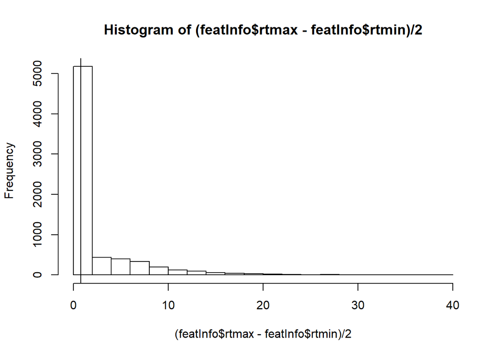

```r
#List of adducts for do.findmain
adducts_list = c("[M+H-H2O]+")

### Building the defineExperiment manually
### Change for your convenience (e.g. GC-MS)
##########################################

value <- c(rep("fill", 4), "LC-MS")
design <- as.data.frame(value)
rownme <- c("Experiment", "Species", "Sample",
            "Contributer", "platform")
rownames(design) <- rownme

######################################################

value <- c(rep("fill", 13), "1")
instrument <- as.data.frame(value)
rownm <- c("chrominst", "msinst", "column",
           "solvA", "solvB", "CE1", "CE2",
           "mstype", "msmode", "ionization",
           "colgas", "msscanrange", "conevol",
           "MSlevs")
rownames(instrument) <- rownm

Experiment <- list(design =  design, instrument = instrument)

output_dir_node9 <- file.path(output_dir, "09-data-reduction")
fs::dir_create(output_dir_node9)
```

```r
sr_neg <- 0.7
st_neg <- getRamSt(peakgrouped_imp_neg)
```

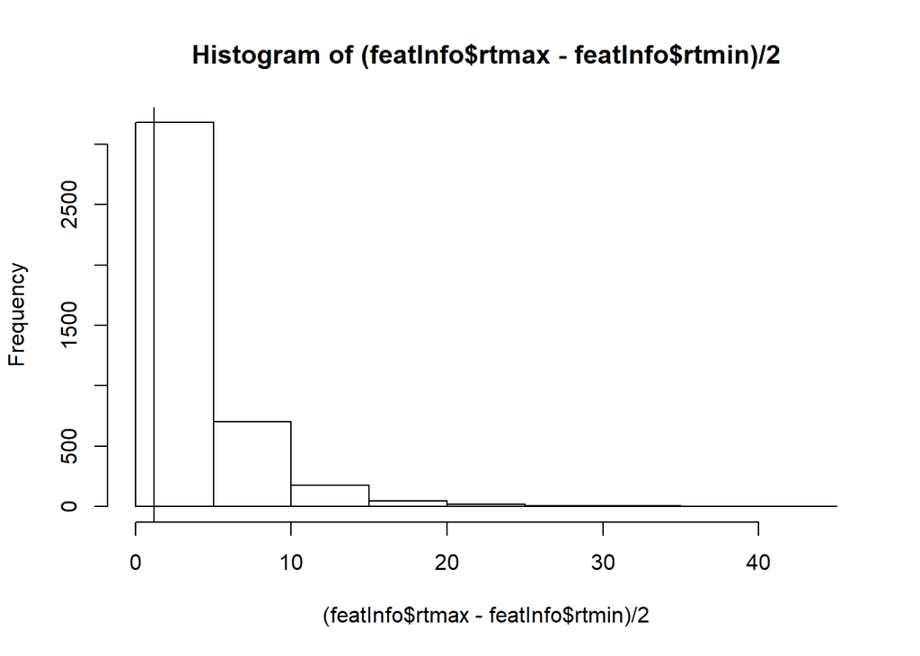

```r
### Building the defineExperiment manually
### Change for your convenience (e.g. GC-MS)
##########################################

value_neg <- c(rep("fill", 4), "LC-MS")
design_neg <- as.data.frame(value_neg)
rownme_neg <- c("Experiment", "Species", "Sample",
            "Contributer", "platform")
rownames(design_neg) <- rownme_neg

######################################################

value_neg <- c(rep("fill", 13), "1")
instrument_neg <- as.data.frame(value_neg)
rownm_neg <- c("chrominst", "msinst", "column",
           "solvA", "solvB", "CE1", "CE2",
           "mstype", "msmode", "ionization",
           "colgas", "msscanrange", "conevol",
           "MSlevs")
rownames(instrument_neg) <- rownm_neg

Experiment_neg <- list(design =  design_neg, instrument = instrument_neg)
```

## Code to run

```r
knitr::opts_knit$set(root.dir = output_dir_node9)
setwd(output_dir_node9)

RC <- clustering(ms = paste0(output_dir_node8,"/xdataImputed.csv"),
                 featdelim = "_",
                 st = st,
                 sr = sr,
                 ExpDes = Experiment,
                 normalize = "TIC",
                 sampNameCol = 1,
                 fftempdir = output_dir_node9)
RC <- do_findmain(RC,
                  nls = adducts_list,
                  mode = "positive",
                  mzabs.error = 0.005,
                  ppm.error = 5,
                  writeMat = FALSE)
```

```r
#We need another folder or do.findmain function rewrite the pdf with
#pseudo spectra, erasing the positive onw
output_dir_node9_neg <- file.path(output_dir, "09-data-reduction_neg")
fs::dir_create(output_dir_node9_neg)
knitr::opts_knit$set(root.dir = output_dir_node9_neg)
setwd(output_dir_node9_neg)

RC_neg <- clustering(ms = paste0(output_dir_node8,"/xdataImputed_neg.csv"),
                     featdelim = "_",
                     st = st_neg,
                     sr = sr_neg,
                     ExpDes = Experiment_neg,
                     normalize = "TIC",
                     sampNameCol = 1,
                     fftempdir = output_dir_node9_neg)

RC_neg <- do_findmain(RC_neg,
                      nls = adducts_list,
                      mode = "negative",
                      mzabs.error = 0.005,
                      ppm.error = 5,
                      writeMat = FALSE)
```

```r
# Selection of max intensity ion as cluster representative
Max_int<- lapply(RC$M.ann, function(x) x[which.max(x$int), ])
Representative_ions <- dplyr::bind_rows(Max_int)
Representative_ions$name <- paste(round(Representative_ions$mz,4),
                             round(RC$clrt,2),
                             sep = "_")

# Adducts of representative ions
Representative_adducts <- sapply(RC$M.ann, function(x) x[which.max(x$int), ]$adduct)

# Selection of labeled max intensity ion as cluster representative
Labeled_int <- lapply(RC$M.ann, function(x) {
  xl <- x[which(!is.na(x$label)), ]
  xl[which.max(xl$int), ]
})
Labeled_ions <- dplyr::bind_rows(Labeled_int)

# We save most important cluster data
cluster_data <- data.frame(cluster = RC$ann, Max_int_ion_mz = Representative_ions$mz,
                           Max_int_ion_adduct = Representative_adducts,
                           labeled_ion_mz = Labeled_ions$mz,
                           labeled_ion_adduct = Labeled_ions$label,
                           RC_mz = RC$M, retention_time = RC$clrt)

# We save cluster features and intensities
cluster_features_fn <- file.path(output_dir_node9, "cluster_features.csv")
file.create(cluster_features_fn)
```

```
## [1] TRUE
```

```r
for (i in seq_len(length(RC$ann))) {
  utils::write.table(RC$ann[i], cluster_features_fn, sep = ',',
                     row.names = FALSE, col.names = FALSE, append = TRUE)
  utils::write.table(t(RC$M.ann[[i]]$mz), cluster_features_fn,
                     sep = ',', row.names = FALSE, col.names = FALSE, append = TRUE)
  utils::write.table(t(RC$M.ann[[i]]$int), cluster_features_fn,
                     sep = ',', row.names = FALSE, col.names = FALSE, append = TRUE)
}

# All labeled ions
All_labeled_adducts <- lapply(RC$M.ann, function(x) {
  xl <- x[which(!is.na(x$label)), ]
})
All_labeled_adducts <- dplyr::bind_rows(All_labeled_adducts)
```

```r
# Selection of max intensity ion as cluster representative
Max_int_neg<- lapply(RC_neg$M.ann, function(x) x[which.max(x$int), ])
Representative_ions_neg <- dplyr::bind_rows(Max_int_neg)
Representative_ions_neg$name <- paste(round(Representative_ions_neg$mz,4),
                             round(RC_neg$clrt,2),
                             sep = "_")

# Adducts of representative ions
Representative_adducts_neg <- sapply(RC_neg$M.ann,
                                     function(x) x[which.max(x$int), ]$adduct)

# Selection of labeled max intensity ion as cluster representative
Labeled_int_neg <- lapply(RC_neg$M.ann, function(x) {
  xl <- x[which(!is.na(x$label)), ]
  xl[which.max(xl$int), ]
})
Labeled_ions_neg <- dplyr::bind_rows(Labeled_int_neg)

# We save most important cluster data
cluster_data_neg <- data.frame(cluster = RC_neg$ann,
                               Max_int_ion_mz = Representative_ions_neg$mz,
                               Max_int_ion_adduct = Representative_adducts_neg,
                               labeled_ion_mz = Labeled_ions_neg$mz,
                               labeled_ion_adduct = Labeled_ions_neg$label,
                               RC_mz = RC_neg$M, retention_time = RC_neg$clrt)

# We save cluster features and intensities
cluster_features_fn <- file.path(output_dir_node9, "cluster_features_neg.csv")
file.create(cluster_features_fn)
```

```
## [1] TRUE
```

```r
for (i in seq_len(length(RC_neg$ann))) {
  utils::write.table(RC_neg$ann[i], cluster_features_fn,
                     sep = ',', row.names = FALSE, col.names = FALSE, append = TRUE)
  utils::write.table(t(RC_neg$M.ann[[i]]$mz), cluster_features_fn,
                     sep = ',', row.names = FALSE, col.names = FALSE, append = TRUE)
  utils::write.table(t(RC_neg$M.ann[[i]]$int), cluster_features_fn,
                     sep = ',', row.names = FALSE, col.names = FALSE, append = TRUE)
}

# All labeled ions
All_labeled_adducts_neg <- lapply(RC_neg$M.ann, function(x) {
  xl <- x[which(!is.na(x$label)), ]
})
All_labeled_adducts_neg <- dplyr::bind_rows(All_labeled_adducts_neg)
```

```r
mz %in% Representative_ions$mz %>% table()
```

```
## .
## FALSE  TRUE
##  5652  1257
```

```r
message("length of features: ", length(mz))
```

```
## length of features: 6909
```

```r
mz_neg %in% Representative_ions_neg$mz %>% table()
```

```
## .
## FALSE  TRUE
##  3350   790
```

```r
message("length of features: ", length(mz_neg))
```

```
## length of features: 4140
```

```r
mdataImputed <- as.matrix(xdataImputed)

# Clustered features
xdata_cluster_ions <- mdataImputed[, mz %in% Representative_ions$mz]

# Singletons
clustered_mz<- lapply(RC$M.ann,
                      function (x) x$mz) %>%
                      unlist() %>%
                      as.numeric()

message("A number of ",
        length(clustered_mz),
        " features have been clustered into ",
        dim(xdata_cluster_ions)[2],
        " representative features")
```

```
## A number of 5199 features have been clustered into 1257 representative features
```

```r
mdataImputed <- as.data.frame(mdataImputed)
xdata_cluster_ions <- as.data.frame(xdata_cluster_ions)

singletons <- mdataImputed[,!mz %in% clustered_mz]

message("A number of ",
        RC$nsing,
        " features correspond to singletons")
```

```
## A number of 1709 features correspond to singletons
```

```r
mdataImputed_neg <- as.matrix(xdataImputed_neg)

# Clustered features
xdata_cluster_ions_neg <- mdataImputed_neg[, mz_neg %in% Representative_ions_neg$mz]

# Singletons
clustered_mz_neg<- lapply(RC_neg$M.ann,
                      function (x) x$mz) %>%
                      unlist() %>%
                      as.numeric()

message("A number of ",
        length(clustered_mz_neg),
        " features have been clustered into ",
        dim(xdata_cluster_ions_neg)[2],
        " representative features")
```

```
## A number of 3057 features have been clustered into 790 representative features
```

```r
mdataImputed_neg <- as.data.frame(mdataImputed_neg)
xdata_cluster_ions_neg <- as.data.frame(xdata_cluster_ions_neg)

singletons_neg <- mdataImputed_neg[,!mz_neg %in% clustered_mz_neg]

message("A number of ",
        RC_neg$nsing,
        " features correspond to singletons")
```

```
## A number of 1082 features correspond to singletons
```

```r
#Combine singletons and molecular ions
xdata_reduced <- cbind.data.frame(xdata_cluster_ions, singletons)

message("Original dataset has ",
        ncol(mdataImputed),
        " features")
```

```
## Original dataset has 6909 features
```

```r
message("Cluster representative ions dataset has ", ncol(xdata_cluster_ions),
        " features")
```

```
## Cluster representative ions dataset has 1257 features
```

```r
message("Singletons dataset has ", ncol(singletons), " features")
```

```
## Singletons dataset has 1710 features
```

```r
message("Reduced dataset has ", ncol(xdata_reduced), " features")
```

```
## Reduced dataset has 2967 features
```

```r
#Combine singletons and molecular ions
xdata_reduced_neg <- cbind.data.frame(xdata_cluster_ions_neg, singletons_neg)

message("Original dataset has ",
        ncol(mdataImputed_neg),
        " features")
```

```
## Original dataset has 4140 features
```

```r
message("Cluster representative ions dataset has ", ncol(xdata_cluster_ions_neg),
        " features")
```

```
## Cluster representative ions dataset has 790 features
```

```r
message("Singletons dataset has ", ncol(singletons_neg), " features")
```

```
## Singletons dataset has 1083 features
```

```r
message("Reduced dataset has ", ncol(xdata_reduced_neg), " features")
```

```
## Reduced dataset has 1873 features
```